# Graphs: Searching

February 24, 2021

# Assignment Comments, Sample Solutions

## Complete Graphs: Recursive structure

Suppose that $\mathcal{L} = (A_1, A_2, \ldots, A_i)$ is the adjacency list for $K_i$, the complete graph on $i$ vertices.

- $A_1 = 2 \rightarrow 3 \rightarrow 4 \rightarrow \cdots \rightarrow i$.
- Describe how you could modify $\mathcal{L}$ to obtain the adjacency list for $K_{i+1}$, the complete graph on $i+1$ vertices. (How would the array change? How would each linked list change?)

> For $i+1$ vertices, simply add vertex $i+1$ to each linked list, and then add an additional linked list to $\mathcal{L}$ that contains all vertices except for $i+1$.

$$A_{i+1} = 1\rightarrow 2 \rightarrow 3 \rightarrow \cdots \rightarrow i$$

## Map graphs and coloring

Guanacaste (1),Alajuela(2), Heredia(3), Limón (4), Cartago (5), San José (6), Puntarenas (7)

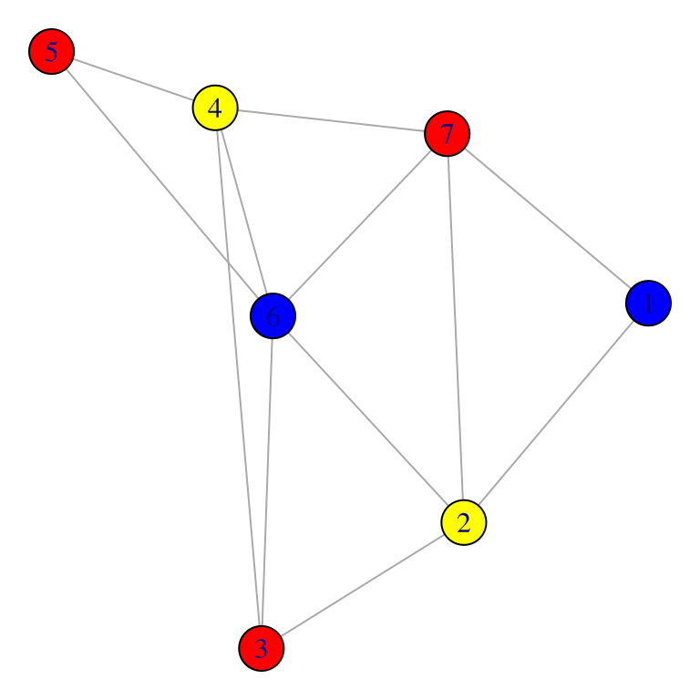

- Three colors suffice as shown.
- Three colors are necessary because the graph contains a $K_3$ subgraph.

## `igraph` plot options

```r
library(igraph) #load the igraph library
costaRica_list <- list(c(2,7),
                    c(1,7,3,6),
                    c(2,4,6),
                    c(5,3,6,7),
                    c(4,6),
                    c(7,5,3,4,2),
                    c(6,4,2,1))
M <- graph_from_adj_list(costaRica_list, mode="all")
oldPar <- par(mar=c(0.1,0.1,0.1,0.1)) # reduce the margins
set.seed(1234) # fix the randomization of the following plot command
plot(M, vertex.color= c("blue","yellow","red","yellow","red","blue","red"))
par(oldPar) # restore the default margins
```

For a list of options for plotting using `igraph`:

```r
?igraph.plotting
```

## Change seed for different configuration

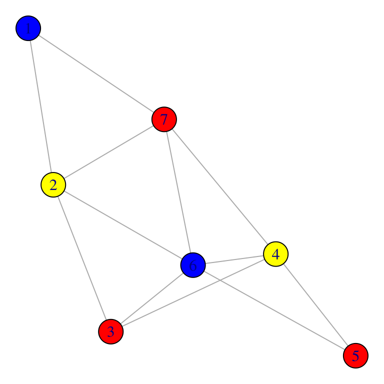

```r
library(igraph) #load the igraph library
costaRica_list <- list(c(2,7),
                    c(1,7,3,6),
                    c(2,4,6),
                    c(5,3,6,7),
                    c(4,6),
                    c(7,5,3,4,2),
                    c(6,4,2,1))
M <- graph_from_adj_list(costaRica_list, mode="all")
oldPar <- par(mar=c(0.1,0.1,0.1,0.1)) # reduce the margins
set.seed(8723) # fix the randomization of the following plot command
plot(M, vertex.color= c("blue","yellow","red","yellow","red","blue","red"))
par(oldPar) # restore the default margins
```

## Fun with labels

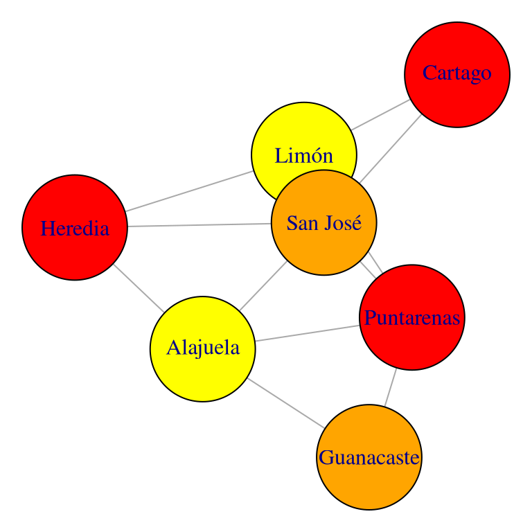

```r
library(igraph) #load the igraph library
costaRica_list <- list(c(2,7),
                    c(1,7,3,6),
                    c(2,4,6),
                    c(5,3,6,7),
                    c(4,6),
                    c(7,5,3,4,2),
                    c(6,4,2,1))
M <- graph_from_adj_list(costaRica_list, mode="all")
oldPar <- par(mar=c(0.1,0.1,0.1,0.1)) # reduce the margins
set.seed(31205) # fix the randomization of the following plot command
plot(M, vertex.color= c("orange","yellow","red","yellow","red","orange","red"),
     vertex.label=c("Guanacaste","Alajuela","Heredia","Limón","Cartago","San José","Puntarenas"),
     vertex.size=55)
par(oldPar) # restore the default margins
```

## Four Color Theorem

> Any *planar graph* can be four colored.
- A planar graph is a graph that can be drawn without edges crossing.
- Graphs made from maps are planar.

[Proof](https://www.ams.org/notices/200811/tx081101382p.pdf)

# Graphs: Representation

## Adjacency Lists

Our default representation will be as an **adjacency list**.

- `A[1..V]` is an *array* of *lists*.
  - Undirected: `A[i]` is a list of neighbors of vertex `i`
  - Directed: `A[i]` is a list of out-neighbors of vertex `i`
    - Default: these are linked lists.

## Aside: Adjacency Matrices

Sometimes it is convenient to represent a graph as a $V \times V$ *matrix*:

$$\begin{bmatrix}
a_{1,1} & a_{1,2} & \cdots & a_{1,V} \\
a_{2,1} & a_{2,2} & \cdots & a_{2,V} \\
\vdots & \vdots && \vdots \\
a_{V,1} & a_{V,2} & \cdots & a_{V,V}
\end{bmatrix}$$

- $a_{i,j} = 1$ if there is an edge from vertex $i$ to vertex $j$.
- $a_{i,j} = 0$ if there isn’t.
- More efficient for *dense* graphs (lots of edges). Less efficient for *sparse* graphs.
- See Figure 5.11.

# Depth-First Search

## DFS = Recursive backtracking

```javascript
RecursiveDFS(v):
    if v is unmarked
        mark v
        for each edge vw
            RecursiveDFS(w)
```

## Recall: Stack

- LIFO: Last in, First out
- `Push(x)` inserts `x` at the top of the stack
- `Pop` removes the element from the top of the stack and returns it.
- Think stack of plates.

## DFS implemented with a stack

```javascript
DepthFirstSearch(s):
    Push(s)
    while the stack is not empty
        v <- Pop
        if v is unmarked
            mark v
            for each edge vw
                Push(w)
```

## Step through

# Breadth-First Search

## Recall: Queue

- FIFO: First in, First out
- `Enqueue(x)` inserts `x` at the back of the queue
- `Dequeue` removes the element from the front of the queue and returns it.
- Think waiting in line.

## BFS: Replace stack with queue

```javascript
BreadthFirstSearch(s):
    Enqueue(s)
    while the queue is not empty
        v <- Dequeue
        if v is unmarked
            mark v
            for each edge vw
                Enqueue(w)
```

## Table Groups

| Table #1 | Table #2 | Table #3 | Table #4 | Table #5 | Table #6 | Table #7 |
| --- | --- | --- | --- | --- | --- | --- |
| Nathan | Kevin | Logan | Ethan | James | Jack | Drake |
| Levi | Isaac | Talia | John | Blake | Josiah | Grace |
| Kristen | Trevor | Bri | Jordan | Claire | Graham | Andrew |

1. Step through BFS on the Jamboard for the given graph and adjacency list. Keep track of the queue and make sure you record the order in which the nodes were visited.
2. How could you modify the DFS and BFS algorithms to deal with *directed* graphs?

# Spanning Trees

## Depth-first spanning tree

Modified `DepthFirstSearch`:

- Store ordered pairs `(p,v)` in the stack, where `p` is the previously visited node.
- Keep track of `parent` attribute for each vertex.
- Every vertex gets a parent, and this defines a tree containing all the vertices, called the *depth-first spanning tree*.

```javascript
DepthFirstSearch(s):                        DepthFirstSearchPlus(s):
    Push(s)                                     Push((∅,s))
    while the stack is not empty                while the stack is not empty
        v <- Pop                                    (p,v) <- Pop
        if v is unmarked                            if v is unmarked
            mark v                                      mark v
            for each edge vw                            v.parent <- p
                Push(w)                                 for each edge vw
                                                            Push((v,w))
```

## Breadth-first spanning tree

Similarly, we can modify `BreadthFirstSearch` to get the *breadth-first spanning tree*.

```javascript
BreadthFirstSearch(s):                      BreadthFirstSearchPlus(s):
    Enqueue(s)                                  Enqueue((∅,s))
    while the queue is not empty                while the queue is not empty
        v <- Dequeue                                (p,v) <- Dequeue
        if v is unmarked                            if v is unmarked
            mark v                                      mark v
            for each edge vw                            v.parent <- p
                Enqueue(w)                              for each edge vw
                                                            Enqueue((v,w))
```

Bonus: The breadth-first spanning tree contains the *shortest path* from `s` to every node.

# WhateverFirstSearch: variations

## Meta-algorithm: WhateverFirstSearch

```javascript
WhateverFirstSearch(s):
    put s into the bag
    while the bag is not empty
        take v from the bag
        if v is unmarked
            mark v
            for each edge vw
                put w into the bag
```

- bag = stack: DFS
- bag = queue: BFS
- bag = priority queue: Best-first search
  - priority = weights: minimum weight spanning tree (Prim)
  - priority = total distance from `s`: shortest paths from `s` (Dijkstra)
  - priority = minimum weight of edges in path from `s`: widest paths (Maximum Flow)

## WhateverFirstSearch Time

```javascript
WhateverFirstSearch(s):
    put s into the bag
    while the bag is not empty
        take v from the bag
        if v is unmarked
            mark v
            for each edge vw
                put w into the bag
```

Time: $O(V + ET)$ where $T$ is the time to insert/delete to/from bag

- DFS: $O(V+E)$
- BFS: $O(V+E)$
- bag = priority queue: $O(V + E \log E)$